# Latent Profiles of HPV Vaccination, Depressive Symptoms, and Metabolic Syndrome Components

Latent Class Analysis of NHANES 2011–2018

Author

Helen Hung (Advisor: Dr. Cohen)

Published

November 9, 2026

## Introduction

Human papillomavirus (HPV) vaccination is an effective strategy for preventing new HPV infections and HPV-associated cancers. In the United States, catch-up vaccination is recommended for all persons through age 26 years, whereas vaccination for adults aged 27–45 years is based on shared clinical decision-making; HPV vaccines are not licensed for use after age 45 years (Centers for Disease Control and Prevention 2024; Meites 2019). These boundaries make age particularly relevant when adult vaccination patterns are examined. Nevertheless, HPV-vaccination coverage among U.S. adults remains incomplete and varies across demographic and health-care-access groups (Lewis and Markowitz 2022; Lu 2021). HPV vaccination may therefore reflect not only receipt of a specific cancer-prevention intervention but also broader differences in access to and engagement with preventive care.

Metabolic syndrome (MetS) is a cluster of five cardiometabolic abnormalities: central adiposity, elevated triglycerides, reduced high-density lipoprotein cholesterol, elevated blood pressure, and impaired glucose regulation (Alberti et al. 2009). MetS is common among U.S. adults, increases markedly with age, and is associated with elevated cardiovascular and all-cause mortality risk (Hirode and Wong 2020; Mottillo et al. 2010). Although MetS is conventionally defined by the presence of any three of its five components, a binary diagnosis treats individuals with different constellations of abnormalities as equivalent (Alberti et al. 2009). Retaining the individual components may therefore provide a more informative account of heterogeneity in cardiometabolic risk.

Depressive symptoms add a clinically important mental-health dimension to this heterogeneity. Meta-analytic evidence supports an association between depression and MetS, including evidence that the relationship may be bidirectional and that individual MetS components differ in their associations with depressive symptoms (Kim et al. 2023; Pan et al. 2012). However, research on HPV vaccination, depressive symptoms, and metabolic health has largely developed along separate lines. Evidence directly addressing depressive symptoms in relation to adult HPV-vaccination patterns is limited. The closest related NHANES research evaluated MetS in relation to HPV infection rather than vaccination and represented MetS primarily as an overall diagnosis (Molokwu et al. 2017). Consequently, little is known about whether HPV vaccination, depressive symptoms, and component-specific metabolic abnormalities form distinct patterns within the adult population.

Latent class analysis (LCA) provides a person-centered approach to this question by identifying unobserved subgroups whose members share similar response patterns across multiple indicators. Prior cancer-prevention research has used LCA to show that health behaviors and risk conditions cluster within population subgroups in ways that may be obscured when each factor is examined separately (Kang et al. 2014). Applying LCA to HPV vaccination, depressive symptoms, and the five MetS components may therefore identify multidomain prevention profiles that are not captured by a binary MetS diagnosis or by a series of variable-centered associations.

Accordingly, this study used NHANES 2011–2018 data from U.S. adults aged 20–59 years to identify latent classes defined by HPV vaccine initiation, elevated depressive symptoms, and the five MetS components, and to describe their conditional response probabilities and assigned-class proportions. Age, sex, education, and marital status were summarized descriptively across the assigned classes. The analysis examines patterns of co-occurrence; it does not establish causal pathways or developmental trajectories.

## Methods

### Latent Class Analysis and Model Assumptions

LCA identifies unobserved groups from response patterns across multiple indicators. This study used seven binary indicators for exploratory LCA: HPV vaccine initiation, elevated depressive symptoms, elevated waist circumference, elevated blood pressure, elevated fasting glucose, low HDL cholesterol, and elevated triglycerides. The model estimates the proportion of each class and the probability of a “yes” response to each indicator within each class. It assumes local independence, meaning that indicator responses are independent given a participant’s latent class (Linzer and Lewis 2011; Sinha et al. 2021).

Let $\mathbf{Y}$ represent a person’s complete set of indicator responses and $\mathbf{y}$ the observed response pattern. The **LCA mixture probability equation** is

$$P(\mathbf{Y}=\mathbf{y})
=\sum_{k=1}^{K}\pi_k
\prod_{j=1}^{J}P(Y_j=y_j\mid C=k)$$

| Symbol | Meaning in this study |
| --- | --- |
| $\mathbf{Y}$, $\mathbf{y}$ | A person’s complete set of indicator responses and the observed response pattern. |
| $Y_j$, $y_j$ | Indicator $j$ and its observed “yes” or “no” response. |
| $C$, $k$ | $C$ represents the latent class, and $k$ identifies a particular class. |
| $K$ | The total number of latent classes. This study compared one- through five-class models and selected three classes, so $K=3$ in the final model. |
| $J$ | The total number of indicators. This study used seven, so $J=7$. |
| $\pi_k=P(C=k)$ | The model-estimated proportion of class $k$. Class proportions range from $0$ to $1$ and satisfy $\sum_{k=1}^{K}\pi_k=1$. |
| $P(Y_j=y_j\mid C=k)$ | The probability of the observed response to indicator $j$ within class $k$. For example, the probability of a “yes” response to low HDL cholesterol within Class 2. |
| $\prod$ | Multiplies the probabilities of the seven responses within the same class. |
| $\sum$ | Adds the results across classes after multiplying each class’s result by its class proportion. |

In this study, each participant has a health profile made up of HPV vaccination, depressive symptoms, and five metabolic indicators. For example, a participant may be unvaccinated against HPV and have elevated blood pressure and fasting glucose. The model combines these responses with the other four indicators to calculate the probability of the complete response pattern within each latent class, then weights those probabilities by the model-estimated class proportions and adds them together. In the selected three-class model, the equation combines information from three health profiles to describe how likely different combinations of indicators are to occur in the data (Linzer and Lewis 2011).

**Local independence assumption.** Given a latent class, this study assumes that responses to HPV vaccination, depressive symptoms, and the five metabolic indicators are independent. For the participant described above, the model multiplies the conditional probabilities of “no HPV vaccination,” “elevated blood pressure,” “elevated fasting glucose,” and the four other observed responses within each class. This assumption concerns relationships within the same latent class. Indicators such as blood pressure and glucose may still be related in the overall sample. BVRs are then used to check how well the estimated classes reproduce the pairwise relationships among these indicators.

### Model Estimation and Selection

One- through five-class models were estimated by maximum likelihood using the R package `poLCA`. Each model was first fitted with 10 alternative starts and then estimated with 10 repetitions, including the best starting probabilities from the first stage. Class selection considered the Bayesian information criterion (BIC), Akaike information criterion (AIC), normalized entropy, class sizes, average posterior classification probabilities, and substantive interpretability. BIC and interpretability were the main criteria (Nylund et al. 2007; Weller et al. 2020; Zhou et al. 2023).

### Class Assignment and Diagnostics

Each participant was assigned to the class with the highest posterior probability. Classes were described and named using the conditional response probabilities of the seven indicators. Pairwise Pearson bivariate residuals (BVRs) compared observed indicator-pair frequencies with model-predicted frequencies to assess local independence (Oberski 2016).

## Analysis and Results

### Study Design and Data Source

This cross-sectional study used publicly available data from four consecutive cycles of the National Health and Nutrition Examination Survey (NHANES): 2011–2012, 2013–2014, 2015–2016, and 2017–2018. NHANES is conducted by the National Center for Health Statistics (NCHS) and uses a complex, multistage probability design to produce estimates for the civilian, noninstitutionalized U.S. population (Chen et al. 2020; National Center for Health Statistics 2018). The survey combines household interviews with standardized examinations and laboratory assessments conducted in mobile examination centers.

The cleaned data set included 5,731 adults aged 20–59 years with complete data on the study variables. Because fasting glucose and triglycerides were included as latent-class indicators, the primary analytic sample was restricted to participants with a positive adjusted fasting-subsample weight (`wtsaf2yrad > 0`), as recommended for analyses that use fasting-subsample measures. This restriction excluded 224 participants and yielded a primary sample of 5,507.

### Measures

**HPV Vaccination.** HPV-vaccination status was derived from the NHANES immunization questionnaire. In the analytic sample of adults aged 20–59 years, this measure recorded whether participants had ever received at least one HPV vaccine dose. The cleaned analytic variable was dichotomized as yes versus no. This measure reflects vaccine initiation, including receipt of a single dose (National Center for Health Statistics 2020b; Lewis and Markowitz 2022).

**Depressive Symptoms.** Depressive symptoms were assessed with the nine-item Patient Health Questionnaire (PHQ-9), which asks about the frequency of depressive symptoms during the preceding two weeks. Items are scored from 0 to 3 and summed to produce a total score ranging from 0 to 27. Consistent with the established validation study and the coding in the analytic data set, high depressive symptoms were defined as a PHQ-9 score of 10 or higher (Kroenke et al. 2001; National Center for Health Statistics 2020c).

**Metabolic Syndrome Components.** Five binary metabolic syndrome (MetS) indicators were included: elevated waist circumference, elevated triglycerides, low high-density lipoprotein cholesterol, elevated blood pressure, and elevated fasting glucose. These indicators correspond to the harmonized MetS framework, under which MetS is defined by the presence of any three or more of the five components (Alberti et al. 2009).

The reference criteria for the five components are elevated waist circumference (at least 102 cm in men or 88 cm in women when using the U.S. cutoffs); triglycerides of at least 150 mg/dL or relevant treatment; HDL cholesterol below 40 mg/dL in men or 50 mg/dL in women or relevant treatment; systolic blood pressure of at least 130 mm Hg, diastolic blood pressure of at least 85 mm Hg, or antihypertensive treatment; and fasting glucose of at least 100 mg/dL or glucose-lowering treatment (Alberti et al. 2009). The analysis used preconstructed indicators from the cleaned file. The upstream implementation of these thresholds and medication rules still requires verification.

**Sociodemographic Characteristics.** Age was grouped into 20–26, 27–45, and 46–59 years. These categories correspond to HPV-vaccination policy boundaries: catch-up vaccination is recommended through age 26, shared clinical decision-making applies to some adults aged 27–45 years, and HPV vaccines are not licensed for adults older than 45 years (Meites 2019). Because the data were collected during 2011–2018 and the shared clinical decision-making recommendation was adopted in 2019, these categories reflect current policy boundaries. Eligibility during data collection depended on the policies in place at that time (Meites 2019).

Sex/gender was coded as female or male based on the NHANES demographic variable. Educational attainment was collapsed into high school or less versus some college or more. Marital status was categorized as married or living with a partner versus never married or previously married. The underlying variables were obtained from the NHANES demographic files (National Center for Health Statistics 2020a).

### Exploratory Data Analysis

Overall weighted percentages used the adjusted fasting-subsample weights for the combined 2011–2018 cycles, together with the NHANES masked variance strata and primary sampling units (Chen et al. 2020; Lumley 2004; National Center for Health Statistics 2018).

The analytic sample was 53.2% female before weighting and 51.8% female after weighting. Survey-weighted percentages were 17.5% for ages 20–26, 45.7% for ages 27–45, and 36.8% for ages 46–59. Some college education or more was reported by 64.2%, and 63.0% were married or partnered.

HPV vaccine initiation was reported by 9.9% in weighted estimates, and 7.2% had elevated depressive symptoms. Elevated waist circumference (53.3%) and fasting glucose (46.4%) were the most common metabolic indicators, followed by low HDL (28.4%), elevated triglycerides (22.5%), and elevated blood pressure (21.8%). See Table 1 for the weighted and unweighted summaries.

Table 1: Participant characteristics (N = 5,507).

| Characteristic | Unweighted n | Unweighted % | Survey-weighted % |
| --- | --- | --- | --- |
| **Age group** |  |  |  |
| 20–26 years | 898 | 16.3 | 17.5 |
| 27–45 years | 2,597 | 47.2 | 45.7 |
| 46–59 years | 2,012 | 36.5 | 36.8 |
| **Sex** |  |  |  |
| Female | 2,927 | 53.2 | 51.8 |
| Male | 2,580 | 46.8 | 48.2 |
| **Education level** |  |  |  |
| High school or less | 2,213 | 40.2 | 35.8 |
| Some college or more | 3,294 | 59.8 | 64.2 |
| **Marital status** |  |  |  |
| Married/Partnered | 3,319 | 60.3 | 63.0 |
| Never/Previously Married | 2,188 | 39.7 | 37.0 |
| **Elevated depressive symptoms** |  |  |  |
| Yes | 428 | 7.8 | 7.2 |
| No | 5,079 | 92.2 | 92.8 |
| **HPV vaccine initiation** |  |  |  |
| Yes | 502 | 9.1 | 9.9 |
| No | 5,005 | 90.9 | 90.1 |
| **Elevated waist circumference** |  |  |  |
| Yes | 2,862 | 52.0 | 53.3 |
| No | 2,645 | 48.0 | 46.7 |
| **Elevated blood pressure** |  |  |  |
| Yes | 1,316 | 23.9 | 21.8 |
| No | 4,191 | 76.1 | 78.2 |
| **Elevated fasting glucose** |  |  |  |
| Yes | 2,604 | 47.3 | 46.4 |
| No | 2,903 | 52.7 | 53.6 |
| **Low HDL cholesterol** |  |  |  |
| Yes | 1,623 | 29.5 | 28.4 |
| No | 3,884 | 70.5 | 71.6 |
| **Elevated triglycerides** |  |  |  |
| Yes | 1,233 | 22.4 | 22.5 |
| No | 4,274 | 77.6 | 77.5 |

### Model Selection

The three-class model had the lowest BIC (38,772.32), with AIC 38,620.20 and entropy 0.659. Although four- and five-class solutions had lower AIC, their BIC values were higher and their smallest assigned groups were approximately 5% of the sample. The three-class solution was retained on the basis of BIC, group sizes, and interpretability (see Table 2 and Figure 1). Its entropy was the highest among the fitted multiclass solutions, but does not indicate perfect classification.

Table 2: Fit statistics for the one- through five-class models.

| Classes | AIC | BIC | Entropy | Smallest assigned class (%) |
| --- | --- | --- | --- | --- |
| 1 | 40,219.69 | 40,265.99 | — | 100.00 |
| 2 | 38,898.94 | 38,998.15 | 0.482 | 38.99 |
| 3 | 38,620.20 | 38,772.32 | 0.659 | 25.68 |
| 4 | 38,584.37 | 38,789.39 | 0.642 | 4.90 |
| 5 | 38,577.18 | 38,835.11 | 0.562 | 5.01 |

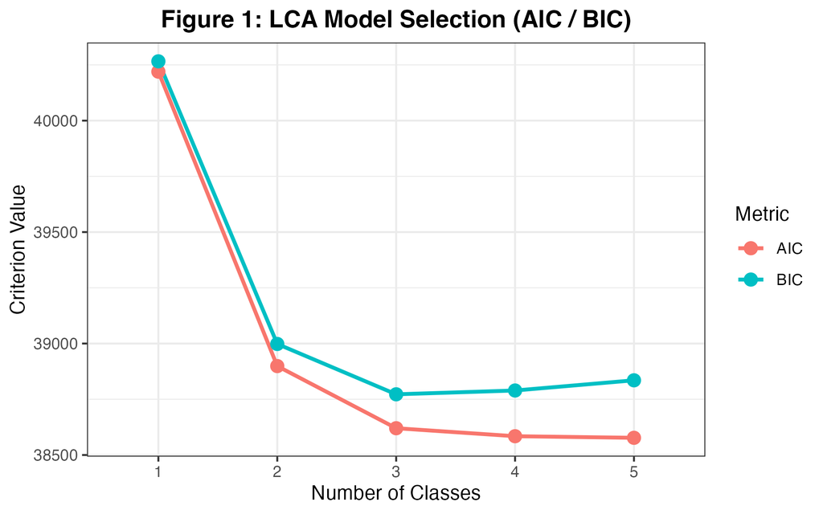

Figure 1: AIC and BIC for the one- through five-class unweighted LCA models.

### Model Diagnostics

Mean posterior membership probabilities for the assigned classes were 0.779, 0.908, and 0.825. Class 1 had the greatest remaining classification uncertainty: its members had an average probability of 0.199 for Class 3. Modal assignments should therefore be treated as uncertain summaries.

Table 3: Average posterior probabilities by assigned class.

| Assigned class | Posterior: Class 1 | Posterior: Class 2 | Posterior: Class 3 |
| --- | --- | --- | --- |
| Assigned Class 1 | 0.779 | 0.022 | 0.199 |
| Assigned Class 2 | 0.092 | 0.908 | <0.001 |
| Assigned Class 3 | 0.175 | <0.001 | 0.825 |

Pairwise BVRs ranged from 0.008 to 4.064. HPV vaccine initiation and elevated waist circumference were the only pair above the screening value of 3.84 (BVR = 4.064). Most pairwise associations were reproduced reasonably well, but this remaining association and the extreme HDL probabilities warrant caution. These diagnostics do not establish that local independence holds exactly.

Table 4: Pairwise Pearson bivariate residuals for the three-class model.

| Indicator | Depressive symptoms | HPV | Waist | BP | Glucose | HDL | Triglycerides |
| --- | --- | --- | --- | --- | --- | --- | --- |
| Elevated depressive symptoms | — | — | — | — | — | — | — |
| HPV vaccine initiation | 0.515 | — | — | — | — | — | — |
| Elevated waist circumference | 2.734 | 4.064 | — | — | — | — | — |
| Elevated blood pressure | 2.325 | 1.721 | 1.477 | — | — | — | — |
| Elevated fasting glucose | 0.53 | 2.991 | 1.325 | 0.344 | — | — | — |
| Low HDL cholesterol | 0.073 | 0.787 | 1.764 | 0.008 | 0.082 | — | — |
| Elevated triglycerides | 0.115 | 1.662 | 3.628 | 1.444 | 2.448 | 0.013 | — |

### Latent Class Profiles

Modal posterior assignment produced 2,029 participants in Class 1 (36.8%), 1,414 in Class 2 (25.7%), and 2,064 in Class 3 (37.5%). These are unweighted assigned-class proportions. The profiles below are described using the model’s conditional response probabilities, which differ from observed percentages in the assigned groups (see Figure 2).

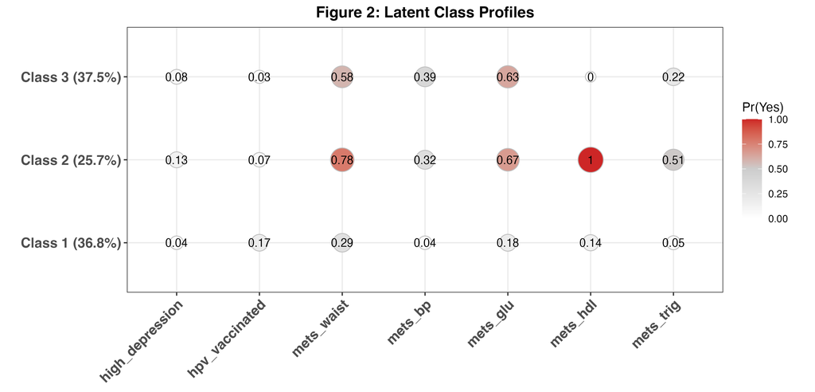

Figure 2: Conditional response probabilities for the three latent classes.

#### Class 1: Relatively Lower Metabolic Burden

Class 1 had the lowest probabilities of elevated blood pressure (0.036), fasting glucose (0.182), triglycerides (0.048), and depressive symptoms (0.041). Its HPV vaccine initiation probability was comparatively higher (0.170), but vaccination remained uncommon. Elevated waist circumference still had a probability of 0.289, so the class should not be interpreted as free of metabolic abnormalities.

#### Class 2: Lipid Abnormalities and Multiple Metabolic Abnormalities

Class 2 had the highest probabilities of low HDL (1.000), elevated waist circumference (0.780), fasting glucose (0.673), and triglycerides (0.511). The probability of elevated depressive symptoms was also highest (0.133), while HPV vaccine initiation was 0.068. The label describes a relative pattern; most members were not estimated to have elevated depressive symptoms.

#### Class 3: Prominent Blood Pressure and Glucose Abnormalities with Low HPV Vaccination

Class 3 had the highest probability of elevated blood pressure (0.388), with prominent elevated fasting glucose (0.633) and waist circumference (0.583). Low HDL had an estimated probability of 0.000, distinguishing this class from Class 2. HPV vaccine initiation was lowest (0.028), and elevated depressive symptoms had a probability of 0.079. The different lipid and blood-pressure patterns make a single low-to-high risk ranking of the classes incomplete.

### Descriptive Characteristics of Assigned Classes

Class 1 was younger and more highly educated: 29% were aged 20–26, 61% were female, and 69% reported some college education or more. Class 2 was 58% female, with 46% reporting high school education or less. Class 3 was older and more male-predominant: 50% were aged 46–59 and 58% were male. These are descriptive comparisons of assigned groups, not adjusted associations or tests of demographic predictors.

Table 5: Observed characteristics within assigned classes (unweighted percentages).

| Characteristic | Class 1: n = 2,029 (36.8%) | Class 2: n = 1,414 (25.7%) | Class 3: n = 2,064 (37.5%) |
| --- | --- | --- | --- |
| **Age group, %** |  |  |  |
| 20–26 years | 29% | 11% | 7.3% |
| 27–45 years | 50% | 50% | 42% |
| 46–59 years | 21% | 39% | 50% |
| **Sex, %** |  |  |  |
| Female | 61% | 58% | 42% |
| Male | 39% | 42% | 58% |
| **Education level, %** |  |  |  |
| High school or less | 31% | 46% | 45% |
| Some college or more | 69% | 54% | 55% |
| **Marital status, %** |  |  |  |
| Married/Partnered | 56% | 63% | 63% |
| Never/Previously Married | 44% | 37% | 37% |
| **Elevated depressive symptoms, %** |  |  |  |
| Yes | 3.4% | 13% | 8.9% |
| No | 97% | 87% | 91% |
| **HPV vaccine initiation, %** |  |  |  |
| Yes | 19% | 5.7% | 1.7% |
| No | 81% | 94% | 98% |
| **Elevated waist circumference, %** |  |  |  |
| Yes | 30% | 78% | 56% |
| No | 70% | 22% | 44% |
| **Elevated blood pressure, %** |  |  |  |
| Yes | 0.4% | 31% | 42% |
| No | 100% | 69% | 58% |
| **Elevated fasting glucose, %** |  |  |  |
| Yes | 3.3% | 66% | 78% |
| No | 97% | 34% | 22% |
| **Low HDL cholesterol, %** |  |  |  |
| Yes | 10% | 100% | 0% |
| No | 90% | 0% | 100% |
| **Elevated triglycerides, %** |  |  |  |
| Yes | 4.3% | 49% | 22% |
| No | 96% | 51% | 78% |

## Conclusion

### Main Findings and Interpretation

The analysis identified three interpretable profiles across HPV vaccine initiation, depressive symptoms, and five MetS components. One profile had relatively lower metabolic burden and comparatively higher vaccine initiation. A second combined low HDL with several metabolic abnormalities and a relatively higher probability of depressive symptoms. A third was distinguished by blood pressure and glucose abnormalities, little low HDL, and very low vaccine initiation.

These results describe heterogeneity in how measured health characteristics co-occur. They illustrate why separate metabolic components can provide useful detail when describing health profiles. The analysis does not establish that this representation predicts outcomes better than a binary MetS diagnosis. The depression–MetS literature motivates studying both health domains together (Kim et al. 2023; Pan et al. 2012), while prior cancer-risk LCA provides a precedent for examining patterns across multiple indicators (Kang et al. 2014). Neither line of evidence validates the exact classes estimated here.

## References

Alberti, Kurt GMM, Robert H Eckel, Scott M Grundy, et al. 2009. “Harmonizing the Metabolic Syndrome: A Joint Interim Statement of the International Diabetes Federation Task Force on Epidemiology and Prevention; National Heart, Lung, and Blood Institute; American Heart Association; World Heart Federation; International Atherosclerosis Society; and International Association for the Study of Obesity.” *Circulation* 120 (16): 1640–45.

Centers for Disease Control and Prevention. 2024. *HPV Vaccine Recommendations*. [Https://www.cdc.gov/hpv/hcp/vaccination-considerations/](https://www.cdc.gov/hpv/hcp/vaccination-considerations/).

Chen, Tsai-Chien, Jon Clark, Michelle K. Riddles, Leyla K. Mohadjer, and Tala H. I. Fakhouri. 2020. *National Health and Nutrition Examination Survey, 2015–2018: Sample Design and Estimation Procedures*. No. 184. Vital and Health Statistics, Series 2. National Center for Health Statistics. https://www.cdc.gov/nchs/data/series/sr_02/sr02-184-508.pdf.

Hirode, Grishma, and Robert J Wong. 2020. “Trends in the Prevalence of Metabolic Syndrome in the United States, 2011-2016.” *JAMA* 323 (24): 2526–28.

Kang, Joseph, Christina Czart Ciecierski, Emily L Malin, et al. 2014. “A Latent Class Analysis of Cancer Risk Behaviors Among US College Students.” *Preventive Medicine* 64: 121–25.

Kim, Hong-Bae, Bethany J Wolf, and Jung-Ha Kim. 2023. “Association of Metabolic Syndrome and Its Components with the Risk of Depressive Symptoms: A Systematic Review and Meta-Analysis of Cohort Studies.” *Journal of Affective Disorders* 323: 46–54.

Kroenke, Kurt, Robert L. Spitzer, and Janet B. W. Williams. 2001. “The PHQ-9: Validity of a Brief Depression Severity Measure.” *Journal of General Internal Medicine* 16 (9): 606–13. https://doi.org/10.1046/j.1525-1497.2001.016009606.x.

Lewis, Rayleen M, and Lauri E Markowitz. 2022. “Disparities in Human Papillomavirus Vaccination Coverage in the United States, National Health and Nutrition Examination Survey, January 2017–March 2020.” *Vaccine* 40 (20): 2828–32.

Linzer, Drew A., and Jeffrey B. Lewis. 2011. “poLCA: An R Package for Polytomous Variable Latent Class Analysis.” *Journal of Statistical Software* 42 (10): 1–29. https://doi.org/10.18637/jss.v042.i10.

Lu, Peng-Jun. 2021. “Surveillance of Vaccination Coverage Among Adult Populations—United States, 2018.” *MMWR Surveillance Summaries* 70.

Lumley, Thomas. 2004. “Analysis of Complex Survey Samples.” *Journal of Statistical Software* 9 (8): 1–19. https://doi.org/10.18637/jss.v009.i08.

Meites, Elissa. 2019. “Human Papillomavirus Vaccination for Adults: Updated Recommendations of the Advisory Committee on Immunization Practices.” *MMWR Morbidity and Mortality Weekly Report* 68.

Molokwu, Jennifer C, Eribeth Penaranda, David S Lopez, Alok Dwivedi, Christopher Dodoo, and Navkiran Shokar. 2017. “Association of Metabolic Syndrome and Human Papillomavirus Infection in Men and Women Residing in the United States.” *Cancer Epidemiology, Biomarkers & Prevention* 26 (8): 1321–27.

Mottillo, Salvatore, Kristian B Filion, Jacques Genest, et al. 2010. “The Metabolic Syndrome and Cardiovascular Risk: A Systematic Review and Meta-Analysis.” *Journal of the American College of Cardiology* 56 (14): 1113–32.

National Center for Health Statistics. 2018. *National Health and Nutrition Examination Survey: Analytic Guidelines, 2011–2016*. Centers for Disease Control; Prevention. https://wwwn.cdc.gov/Nchs/data/nhanes/analyticguidelines/11-16-analytic-guidelines.pdf.

National Center for Health Statistics. 2020a. *National Health and Nutrition Examination Survey 2017–2018 Data Documentation, Codebook, and Frequencies: Demographic Variables and Sample Weights (DEMO_J)*. Centers for Disease Control; Prevention. https://wwwn.cdc.gov/nchs/data/nhanes/public/2017/datafiles/DEMO_J.htm.

National Center for Health Statistics. 2020b. *National Health and Nutrition Examination Survey 2017–2018 Data Documentation, Codebook, and Frequencies: Immunization (IMQ_J)*. Centers for Disease Control; Prevention. https://wwwn.cdc.gov/Nchs/Data/Nhanes/Public/2017/DataFiles/IMQ_J.htm.

National Center for Health Statistics. 2020c. *National Health and Nutrition Examination Survey 2017–2018 Data Documentation, Codebook, and Frequencies: Mental Health – Depression Screener (DPQ_J)*. Centers for Disease Control; Prevention. https://wwwn.cdc.gov/Nchs/Data/Nhanes/Public/2017/DataFiles/DPQ_J.htm.

Nylund, Karen L., Tihomir Asparouhov, and Bengt O. Muthén. 2007. “Deciding on the Number of Classes in Latent Class Analysis and Growth Mixture Modeling: A Monte Carlo Simulation Study.” *Structural Equation Modeling: A Multidisciplinary Journal* 14 (4): 535–69. https://doi.org/10.1080/10705510701575396.

Oberski, Daniel L. 2016. “Beyond the Number of Classes: Separating Substantive from Non-Substantive Dependence in Latent Class Analysis.” *Advances in Data Analysis and Classification* 10 (2): 171–82. https://doi.org/10.1007/s11634-015-0211-0.

Pan, An, NaNa Keum, Olivia I Okereke, et al. 2012. “Bidirectional Association Between Depression and Metabolic Syndrome: A Systematic Review and Meta-Analysis of Epidemiological Studies.” *Diabetes Care* 35 (5): 1171–80.

Sinha, Pratik, Carolyn S. Calfee, and Kevin L. Delucchi. 2021. “Practitioner’s Guide to Latent Class Analysis: Methodological Considerations and Common Pitfalls.” *Critical Care Medicine* 49 (1): e63–79. https://doi.org/10.1097/CCM.0000000000004710.

Weller, Bridget E., Natasha K. Bowen, and Sarah J. Faubert. 2020. “Latent Class Analysis: A Guide to Best Practice.” *Journal of Black Psychology* 46 (4): 287–311. https://doi.org/10.1177/0095798420930932.

Zhou, W., M.-M. He, F. Wang, R.-H. Xu, F. Wang, and Q. Zhao. 2023. “Latent Class Analysis-Derived Classification Improves the Cancer-Specific Death Stratification of Molecular Subtyping in Colorectal Cancer.” *Npj Precision Oncology* 7: 60. https://doi.org/10.1038/s41698-023-00412-w.